# Analysis on severe weather events in the USA

Reproducible Research: Peer-graded Assignment 2 Johns Hopkins University

Luis Escobar Sawa

November 12, 2022

## Introduction

The goal of this study will be to try to address the following questions:

1. Across the United States, which types of events are most harmful with respect to population health?
2. Across the United States, which types of events have the greatest economic consequences?

We will use the storm database provided by the U.S. National Oceanic and Atmospheric Administration’s (NOAA). This database reports estimates of any fatalities, injuries, and property damage caused by major storms and weather events.

We will see that Tornadoes are the events most harmful to population health, whereas Floods are the cause of most economic harm.

## Data Processing

### Extracting the data

We are going to use the *tidyverse* library which is a collection of useful libraries like, dplyr, tibble, ggplot2 and readr, among others. *gridExtra* will be used for ease of plotting.

```r
library(tidyverse)
library(gridExtra)
```

First we download the database if not already present in the repository.

```r
dataDir <- "database/"
dataFile <- paste0(dataDir, "NOAA_stormdatabase.csv.bz2")
dataURL <- "https://d396qusza40orc.cloudfront.net/repdata%2Fdata%2FStormData.csv.bz2"

if(!dir.exists(dataDir)){
    dir.create(dataDir)
}

if(!file.exists(dataFile)){
    download.file(dataURL, dataFile)
}
```

We read the first observation to get the information on the columns present in the dataset.

```r
data <- read_csv(dataFile, n_max = 1, show_col_types = FALSE)
spec(data)
```

For this study, we will only keep the following columns:

- BGN_DATE: The date of the start of the observation. While not completely relevant for this study, it will prove useful in some decisions.
- EVTYPE: The type of the event observed. It is the main variable that we will be looking at.
- FATALITIES: The number of fatalities caused by each event and is, of course, a key variable to investigate impact on population health.
- INJURIES: The number of injuries caused by each event. This is the second variable we will use with regard to population health.
- PROPDMG: The amount of property damage caused by the event in USD.
- PROPDMGEXP: The magnitude of the property damage in the previous column.
- CROPDMG: The amount of damage to crops caused by the event in USD.
- CROPDMGEXP: The magnitude of the damage to crops in the previous column.

```r
data <- read_csv(dataFile, col_types = cols_only(
  BGN_DATE = col_date("%m/%d/%Y 0:00:00"),
  EVTYPE = col_character(),
  FATALITIES = col_double(),
  INJURIES = col_double(),
  PROPDMG = col_double(),
  PROPDMGEXP = col_character(),
  CROPDMG = col_double(),
  CROPDMGEXP = col_character()))
```

```r
data <- subset(data, FATALITIES > 0 | INJURIES > 0 | PROPDMG > 0 | CROPDMG > 0)
```

### Tidying the data

First, we will replace the *BGN_DATE* column by its year, dropping the information on month and day.

```r
data <- mutate(data, YEAR=as.numeric(format(BGN_DATE, "%Y")), .keep = "unused")
```

The variables *PROPDMGEXP* and *CROPDMGEXP* contain the order of magnitude of the variables *PROPDMG* and *CROPDMG* respectively. Since it contains some letters as well as numbers, a direct conversion cannot be done. This is why we create a map, mapping the character to its corresponding number. We then create new variables *REAL_PROPDMG* and *REAL_CROPDMG* with the quantities in single dollars.

```r
map <- data.frame(letter=c("b", "m", "k", "h", "0", "1", "2", "3", "4", "5", "6", "7", "8", "9"),
                  value =c( 9 ,  6 ,  3 ,  2 , 0:9))

data$PROPDMGEXP <- map$value[match(tolower(data$PROPDMGEXP), map$letter)]
data$CROPDMGEXP <- map$value[match(tolower(data$CROPDMGEXP), map$letter)]

data <- data %>% mutate(REAL_PROPDMG = PROPDMG * 10^(PROPDMGEXP), .keep = "unused") %>%
                 mutate(REAL_CROPDMG = CROPDMG * 10^(CROPDMGEXP), .keep = "unused")
```

And lastly, we will clean the EVTYPE variable. Currently it contains 485 different events.

```r
n_distinct(unique(data$EVTYPE))
```

```
## [1] 485
```

The NOAA has defined 48 different event types:

1. Astronomical Low Tide
2. Avalanche
3. Blizzard
4. Coastal Flood
5. Cold/Wind Chill
6. Debris Flow
7. Dense Fog
8. Dense Smoke
9. Drought
10. Dust Devil
11. Dust Storm
12. Excessive Heat
13. Extreme Cold/Wind Chill
14. Flash Flood
15. Flood
16. Frost/Freeze
17. Funnel Cloud
18. Freezing Fog
19. Hail
20. Heat
21. Heavy Rain
22. Heavy Snow
23. High Surf
24. High Wind
25. Hurricane (Typhoon)
26. Ice Storm
27. Lake-Effect Snow
28. Lakeshore Flood
29. Lightning
30. Marine Hail
31. Marine High Wind
32. Marine Strong Wind
33. Marine Thunderstorm Wind
34. Rip Current
35. Seiche
36. Sleet
37. Storm Surge/Tide
38. Strong Wind
39. Thunderstorm Wind
40. Tornado
41. Tropical Depression
42. Tropical Storm
43. Tsunami
44. Volcanic Ash
45. Waterspout
46. Wildfire
47. Winter Storm
48. Winter Weather

The following code tries to gather the different event types under the event types defined by the NOAA. The goal is to assign each of the original 485 to one or more NOAA events. The variable *evtypes_map* will map the original event types to a string that, when run over by a regex pattern, will find the corresponding NOAA events. If no event type could be ascertained, the event will be assigned to *“other”*.

```r
evtypes_map <-  setNames(as_tibble(unique(data$EVTYPE)), c("EVTYPE")) %>%
                mutate(replace=tolower(EVTYPE))  %>%
                mutate(replace=gsub("  ", " ", replace)) %>%
                mutate(replace=gsub("avalance", "avalanche", replace)) %>%
                mutate(replace=gsub("cstl", "coastal", replace)) %>%
                mutate(replace=gsub("astronomical high tide", "coastal flood", replace)) %>%
                mutate(replace=gsub("coastal surge", "coastal flood", replace)) %>%
                mutate(replace=gsub("high tides", "coastal flood", replace)) %>%
                mutate(replace=gsub("coastalstorm", "coastal storm", replace)) %>%
                mutate(replace=gsub("hypothermia", "cold", replace)) %>%
                mutate(replace=gsub("low temperature", "cold", replace)) %>%
                mutate(replace=gsub("land", "debris flow", replace)) %>%
                mutate(replace=gsub("(mud|rock) *slide", "debris flow", replace)) %>%
                mutate(replace=gsub("fog", "dense fog", replace)) %>%
                mutate(replace=gsub("blowing dust", "dust storm", replace)) %>%
                mutate(replace=gsub("flash(?! flood)", "flash flood", replace, perl=TRUE)) %>%
                mutate(replace=gsub("dam break", "flood", replace)) %>%
                mutate(replace=gsub("fld", "flood", replace)) %>%
                mutate(replace=gsub("warm", "heat", replace)) %>%
                mutate(replace=gsub("hyperthermia", "heat", replace)) %>%
                mutate(replace=gsub("falling", "heavy", replace)) %>%
                mutate(replace=gsub("hvy", "heavy", replace)) %>%
                mutate(replace=gsub("rainfall", "heavy rain", replace)) %>%
                mutate(replace=gsub("(?<!heavy )rain", "heavy rain", replace, perl=TRUE)) %>%
                mutate(replace=gsub("precip", "heavy rain", replace)) %>%
                mutate(replace=gsub("heavy mix", "heavy rain", replace)) %>%
                mutate(replace=gsub("heavy shower", "heavy rain", replace)) %>%
                mutate(replace=gsub("excessive snow", "heavy snow", replace)) %>%
                mutate(replace=gsub("(?<!heavy )snow", "heavy snow", replace, perl=TRUE)) %>%
                mutate(replace=gsub("gusty wind", "heavy wind", replace)) %>%
                mutate(replace=gsub("hazardous", "high", replace)) %>%
                mutate(replace=gsub("heavy surf", "high surf", replace)) %>%
                mutate(replace=gsub("rough surf", "high surf", replace)) %>%
                mutate(replace=gsub("heavy swells", "high surf", replace)) %>%
                mutate(replace=gsub("heavy seas", "high surf", replace)) %>%
                mutate(replace=gsub("high waves", "high surf", replace)) %>%
                mutate(replace=gsub("rough seas", "high surf", replace)) %>%
                mutate(replace=gsub("rogue wave", "high surf", replace)) %>%
                mutate(replace=gsub("severe turbulence", "high surf", replace)) %>%
                mutate(replace=gsub("lake effect", "lake-effect", replace)) %>%
                mutate(replace=gsub("lake-effect heavy snow", "lake-effect snow", replace)) %>%
                mutate(replace=gsub("lake flood", "lakeshore flood", replace)) %>%
                mutate(replace=gsub("ligh*n*tn*ing", "lightning", replace)) %>%
                mutate(replace=gsub("mircoburst", "microburst", replace)) %>%
                mutate(replace=gsub("non-thunderstorm", "non thunderstorm", replace)) %>%
                mutate(replace=gsub("precipitation", "rain", replace)) %>%
                mutate(replace=gsub("gradient wind", "rip current", replace)) %>%
                mutate(replace=gsub("storm surge", "storm tide", replace)) %>%
                mutate(replace=gsub("heavy wind", "strong wind", replace)) %>%
                mutate(replace=gsub("non-severe wind damage", "strong wind", replace)) %>%
                mutate(replace=gsub("wind damage", "strong wind", replace)) %>%
                mutate(replace=gsub("^wind$", "strong wind", replace)) %>%
                mutate(replace=gsub("^winds$", "strong wind", replace)) %>%
                mutate(replace=gsub("storm force winds", "strong wind", replace)) %>%
                mutate(replace=gsub("non thunderstorm wind", "strong wind", replace)) %>%
                mutate(replace=gsub("swells", "surf", replace)) %>%
                mutate(replace=gsub("tstm", "thunderstorm", replace)) %>%
                mutate(replace=gsub("th*un*d*e+re*s*tr*or*ms*", "thunderstorm", replace)) %>%
                mutate(replace=gsub("downburst", "thunderstorm wind", replace)) %>%
                mutate(replace=gsub("microburst", "thunderstorm wind", replace)) %>%
                mutate(replace=gsub("thunderstorm wi$", "thunderstorm wind", replace)) %>%
                mutate(replace=gsub("thunderstormw", "thunderstorm wind", replace)) %>%
                mutate(replace=gsub("whirlwind", "thunderstorm wind", replace)) %>%
                mutate(replace=gsub("gustnado", "thunderstorm wind", replace)) %>%
                mutate(replace=gsub("wind storm", "thunderstorm wind", replace)) %>%
                mutate(replace=gsub("(^|severe )thunderstorm($| damage to)", "thunderstorm wind", replace)) %>%
                mutate(replace=gsub("coastal storm", "thunderstorm wind", replace)) %>%
                mutate(replace=gsub("torndao", "tornado", replace)) %>%
                mutate(replace=gsub("fire", "wildfire", replace)) %>%
                mutate(replace=gsub("windchill", "wind chill", replace)) %>%
                mutate(replace=gsub("wins", "wind", replace)) %>%
                mutate(replace=gsub("freezing drizzle", "winter weather", replace)) %>%
                mutate(replace=gsub("freezing rain", "winter weather", replace)) %>%
                mutate(replace=gsub("glaze", "winter weather", replace)) %>%
                mutate(replace=gsub("ice(?! storm)", "winter weather", replace, perl=TRUE)) %>%
                mutate(replace=gsub("icy roads", "winter weather", replace)) %>%
                mutate(replace=gsub("light snow", "winter weather", replace)) %>%
                mutate(replace=gsub("wintry mix", "winter weather", replace)) %>%
                mutate(replace=gsub("freezing spray", "winter weather", replace))
```

```r
NOAA_evtypes <- c("Astronomical Low Tide", "Avalanche", "Blizzard", "Coastal Flood",
                  "Cold", "Wind Chill", "Debris Flow", "Dense Fog", "Dense Smoke",
                  "Drought", "Dust Devil", "Dust Storm", "Excessive Heat", "Extreme Cold",
                  "Wind Chill", "Flash Flood", "Flood", "Frost", "Freeze", "Funnel Cloud",
                  "Freezing Fog", "Hail", "Heat", "Heavy Rain", "Heavy Snow", "High Surf",
                  "High Wind", "Hurricane", "Typhoon", "Ice Storm", "Lake-Effect Snow",
                  "Lakeshore Flood", "Lightning", "Marine Hail", "Marine High Wind",
                  "Marine Strong Wind", "Marine Thunderstorm Wind", "Rip Current",
                  "Seiche", "Sleet", "Storm Surge", "Storm Tide", "Strong Wind",
                  "Thunderstorm Wind", "Tornado", "Tropical Depression", "Tropical Storm",
                  "Tsunami", "Volcanic Ash", "Waterspout", "Wildfire", "Winter Storm",
                  "Winter Weather", "Other")

noaa_evtypes <- tolower(NOAA_evtypes)
noaa_patterns <- paste0("(", paste(noaa_evtypes, collapse = "|"), ")")

# Event types that fail to match to NOAA event types are assigned to "other"
# Only 17 of the original events fall into this category for a total of 62 observations.
evtypes_map$replace[!grepl(noaa_patterns, evtypes_map$replace)] = "other"

data$EVTYPE <- evtypes_map$replace[match(data$EVTYPE, evtypes_map$EVTYPE)]
```

Some of the original events appear to belong to multiple NOAA events, such as ICE STORM/FLASH FLOOD or HURRICANE OPAL/HIGH WINDS. To solve this issue, the original event will be divided into multiple parts and each will be assigned to a different individual NOAA event. This way the global impact of the event is preserved while also trying to keep all the original information.

```r
results <- list(evtype=unique(data$EVTYPE),
                matches=regmatches(unique(data$EVTYPE),
                gregexec(noaa_patterns, unique(data$EVTYPE))))

addition <- tibble(
  YEAR = numeric(),
  EVTYPE = character(),
  FATALITIES = double(),
  INJURIES = double(),
  REAL_PROPDMG = double(),
  REAL_CROPDMG = double())

for(i in 1:nrow(data)){
  matches <- results$matches[results$evtype == data$EVTYPE[i]][[1]][1,]

  number <- length(matches)

  common_divisor <- number
  data$EVTYPE[i]       <- matches[1]

  if(number == 1){
    next
  }

  data$FATALITIES[i]   <- data$FATALITIES[i]   / common_divisor
  data$INJURIES[i]     <- data$INJURIES[i]     / common_divisor
  data$REAL_PROPDMG[i] <- data$REAL_PROPDMG[i] / common_divisor
  data$REAL_CROPDMG[i] <- data$REAL_CROPDMG[i] / common_divisor

  number <- number - 1

  for(j in 1:number){
    addition <- add_row(addition,
                    EVTYPE = matches[1+j],
                    FATALITIES = data$FATALITIES[i],
                    INJURIES = data$INJURIES[i],
                    REAL_PROPDMG = data$REAL_PROPDMG[i],
                    REAL_CROPDMG = data$REAL_CROPDMG[i],
                    YEAR = data$YEAR[i]
           )
  }
}

data <- rbind(data, addition)
```

We are interested in total damage per event type and therefore a sum over all the observations per event type is required. However, we notice that the earlier years (1950s to 1980s) contain almost exclusively tornado events. Other events were not recorded.

In order to mitigate this phenomenon, we will average the impact of each event by the number of years since its first occurrence. The running assumption is that once an event has been recorded once, it will keep being recorded in the future. If it is missing from a subsequent year, it is no longer a lack of recording but a lack of actual event.

```r
summary_per_year <- data %>%
                    group_by(EVTYPE, YEAR) %>%
                    summarise(FATALITIES=sum(FATALITIES, na.rm = TRUE),
                              INJURIES=sum(INJURIES, na.rm = TRUE),
                              PROPDMG=sum(REAL_PROPDMG, na.rm = TRUE)/1e6,
                              CROPDMG=sum(REAL_CROPDMG, na.rm = TRUE)/1e6)
```

```r
summary_mean <- summary_per_year %>%
                group_by(EVTYPE) %>%
                summarise(FATALITIES=sum(FATALITIES, na.rm = TRUE)/(2012-min(YEAR)),
                          INJURIES=sum(INJURIES, na.rm = TRUE)/(2012-min(YEAR)),
                          PROPDMG=sum(PROPDMG, na.rm = TRUE)/(2012-min(YEAR)),
                          CROPDMG=sum(CROPDMG, na.rm = TRUE)/(2012-min(YEAR)))

summary_order <- summary_mean %>%
                 group_by(EVTYPE) %>%
                 summarise(HEALTH=FATALITIES+INJURIES,
                           ECONOMY=PROPDMG+CROPDMG)

summary_health <- summary_mean %>%
                  pivot_longer(2:3, values_to = "quantity", names_to = "health_type") %>%
                  select(-c("PROPDMG", "CROPDMG"))


summary_economy <- summary_mean %>%
                   pivot_longer(4:5, values_to = "amount", names_to = "damage_type") %>%
                   select(-c("FATALITIES", "INJURIES"))
```

## Exploratory Data Analysis

Let us have a look at how the data is distributed:

```r
summary(summary_order)
```

```
##     EVTYPE              HEALTH            ECONOMY
##  Length:51          Min.   :   0.000   Min.   :   0.001
##  Class :character   1st Qu.:   0.485   1st Qu.:   0.364
##  Mode  :character   Median :  22.605   Median :  18.287
##                     Mean   :  88.338   Mean   : 450.468
##                     3rd Qu.:  61.100   3rd Qu.: 354.242
##                     Max.   :1564.973   Max.   :8488.477
```

We can see that the maximum value for HEALTH and ECONOMY is very far from the median, but also from the third quartile.

```r
bplot1 <- ggplot(data = summary_order, aes(x="HEALTH", y=HEALTH/max(HEALTH)))  + geom_boxplot() +
  geom_jitter(position=position_jitter(0.3)) + theme_bw() +
  labs(title="",
       x = "",
       y = "")
bplot2 <- ggplot(data = summary_order, aes(x="ECONOMY", y=ECONOMY/max(ECONOMY)))  + geom_boxplot() +
  geom_jitter(position=position_jitter(0.3)) + theme_bw() +
  labs(title="",
       x = "",
       y = "")
```

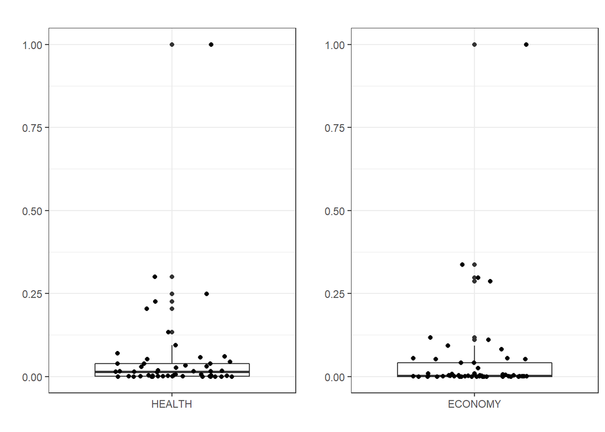

```r
grid.arrange(bplot1, bplot2, ncol=2, name="test")
```

For this reason, we will only look into the last quartile in each category, which corresponds to twelve event types.

## Results

```r
# Color palette for plots
cbPalette <- c("#000000", "#E69F00", "#56B4E9", "#009E73", "#F0E442", "#0072B2", "#D55E00", "#CC79A7")
```

### Impact on population health

We can clearly see that the most harmful events to population health are Tornadoes with more than three times the impact of the second most harmful event type.

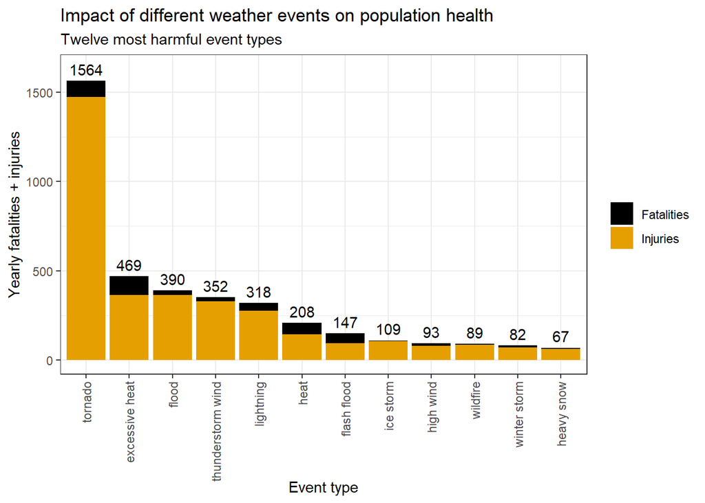

```r
ggplot(data=summary_health, aes(x=reorder(EVTYPE, -quantity), y=quantity, fill=health_type)) +
  geom_bar(stat = "identity") +
  scale_x_discrete(limits=arrange(summary_order,desc(HEALTH))$EVTYPE[1:12]) +
  labs(title="Impact of different weather events on population health",
       subtitle = "Twelve most harmful event types",
       x = "Event type",
       y = "Yearly fatalities + injuries") +
  scale_fill_manual(values = cbPalette,
                    name="",
                    labels=c("Fatalities", "Injuries")) +
  geom_text(aes(EVTYPE, HEALTH + 65, label=as.integer(HEALTH), fill=NULL), data=summary_order) +
  theme_bw() +
  theme(axis.text.x = element_text(angle=90, vjust = 0.5, hjust=1))
```

### Impact on the economy

The most impactful events to the economy are floods with more than 8 488 millions USD of total damages each year.

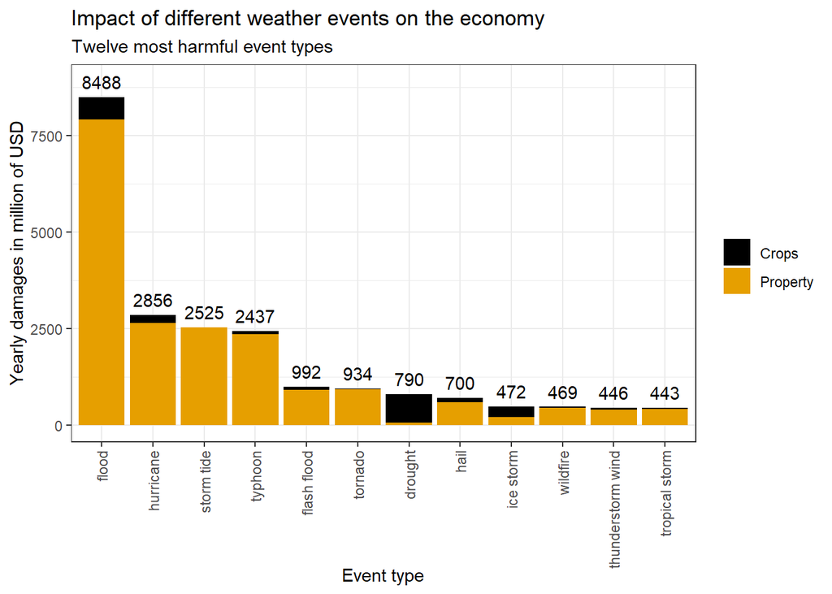

```r
ggplot(data=summary_economy, aes(x=reorder(EVTYPE, -amount), y=amount, fill=damage_type)) +
  geom_bar(stat = "identity") +
  scale_x_discrete(limits=arrange(summary_order,desc(ECONOMY))$EVTYPE[1:12]) +
  labs(title="Impact of different weather events on the economy",
       subtitle = "Twelve most harmful event types",
       x = "Event type",
       y = "Yearly damages in million of USD") +
  scale_fill_manual(values = cbPalette,
                    name="",
                    labels=c("Crops", "Property")) +
  geom_text(aes(EVTYPE, ECONOMY + 400, label=round(ECONOMY,0), fill=NULL), data=summary_order) +
  theme_bw() +
  theme(axis.text.x = element_text(angle=90, vjust = 0.5, hjust=1))
```